# Week 52, 2019 - Socks

From Kathy Bischoping comes a question we’ve all asked ourselves at one time or another:

I have 10 pairs of socks in a drawer. Each pair is distinct from another and consists of two matching socks. Alas, I’m negligent when it comes to folding my laundry, and so the socks are not folded into pairs. This morning, fumbling around in the dark, I pull the socks out of the drawer, randomly and one at a time, until I have a matching pair of socks among the ones I’ve removed from the drawer.

On average, how many socks will I pull out of the drawer in order to get my first matching pair?

[Here is this week’s riddler](https://fivethirtyeight.com/features/can-you-find-a-matching-pair-of-socks/)

```r
#here are my socks
socks <- rep(LETTERS[1:10], 2)

#set up iteration
set.seed(1)
iter <- 1e4
number_of_socks <- rep(NA, iter)

#create a function that will count number of
find_sock_pair <- function() {
  # do all possible draws of socks
  sock_samples <- sample(socks, length(socks))

  #initial draw of a sock
  i <- 1

  #check until we have at least 2 socks
  while(!2 %in% Rfast::Table(sock_samples[1:(i+1)])) {i <- i + 1}

  return(i + 1)
}

#run the oteration
for(draw in 1:iter) {
  #add number of draws for each iteration
  number_of_socks[draw] <- find_sock_pair() #add one as we count the first draw as well
}

#show
summary(number_of_socks)
```

```
##    Min. 1st Qu.  Median    Mean 3rd Qu.    Max.
##   2.000   4.000   6.000   5.677   7.000  11.000
```

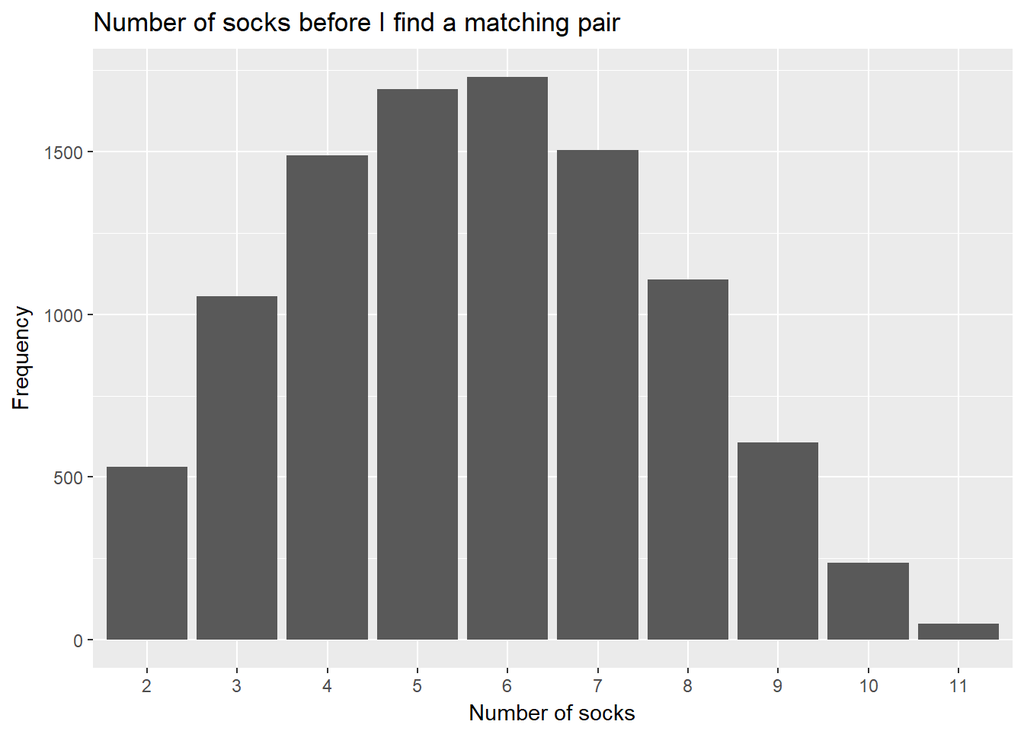

```r
qplot(as.factor(number_of_socks)) +
  labs(title = "Number of socks before I find a matching pair",
       x = "Number of socks",
       y = "Frequency")
```

On average I have to pull out 5.7 socks from the drawer to find a matching pair.

Instead of 10 pairs of socks, what if I have some large number N pairs of socks? *Warning: This takes a few minutes to run*

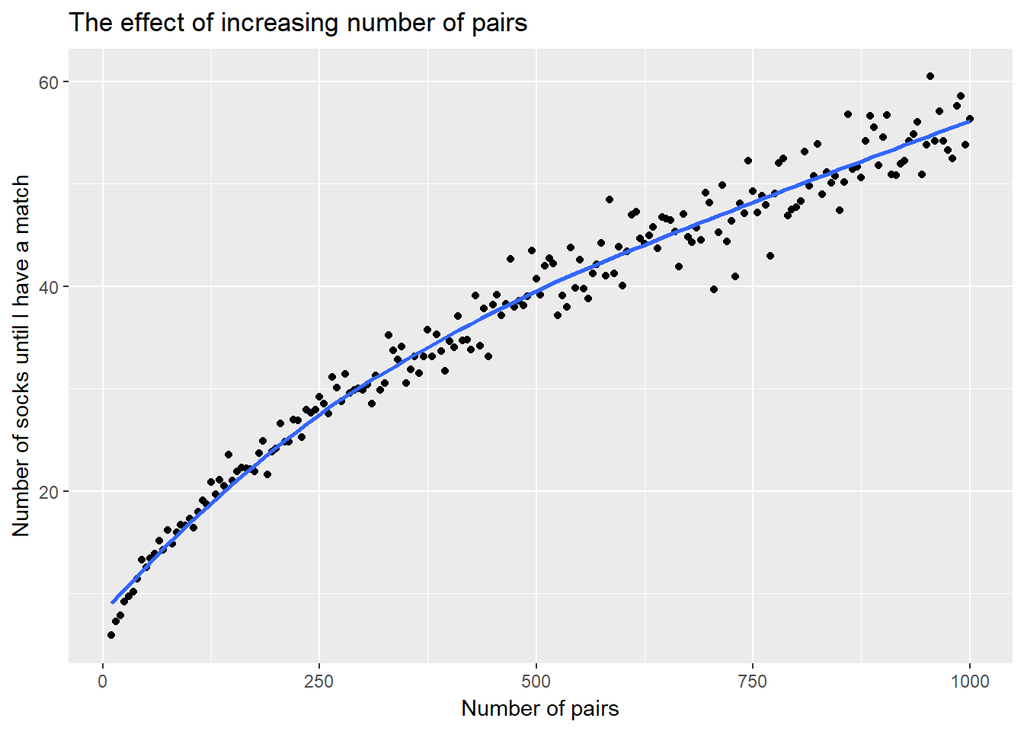

```r
# set up objects for iteration
iter <- 100 #to prevent from running too long we will take a smaller sample and draw a trend line
number_of_pairs <- seq(10, 1000, by = 5)
mean_number_of_socks <- rep(NA, length(number_of_pairs))
number_of_socks <- rep(list(rep(NA, iter)), length(number_of_pairs))

for(j in seq_along(number_of_pairs)) {
  #here are my socks
  socks <- rep(1:number_of_pairs[j], 2)


 for(draw in 1:iter) {
    #add
    number_of_socks[[j]][draw] <- find_sock_pair() ##find number of socks
  }

  mean_number_of_socks[j] <- mean(number_of_socks[[j]])
}

# plot
qplot(number_of_pairs, mean_number_of_socks) +
  geom_smooth(se = FALSE) +
  labs(title = "The effect of increasing number of pairs",
       x = "Number of pairs",
       y = "Number of socks until I have a match")
```

The number of socks I need to pull out doesn’t grow linearly…there is a diminishing return…